# Lab 10: Plyr and Split-Apply-Combine

Statistical Computing, 36-350

Week of Friday July 27, 2018

Name: Gabriel Krotkov Andrew ID: gkrotkov Collaborated with:

This lab is to be done in class (completed outside of class if need be). You can collaborate with your classmates, but you must identify their names above, and you must submit **your own** lab as an knitted HTML file on Canvas, by Friday 10pm, this week.

**This week’s agenda**: practicing split-apply-combine, getting familiar with plyr functions.

# Strikes data set

Data on the political economy of strikes (from Bruce Western, in the Sociology Department at Harvard University) is up at https://raw.githubusercontent.com/linnylin92/36-350_public/master/dat/strikes.csv. The data features 18 countries of 35 years. The measured variables:

- `country`, `year`: country and year of data collection
- `strike.volume`: days on strike per 1000 workers
- `unemployment`: unemployment rate
- `inflation`: inflation rate
- `left.parliament`: leftwing share of the goverment
- `centralization`: centralization of unions
- `density`: density of unions

We read it into our R session below.

```r
strikes.df =
  read.csv("https://raw.githubusercontent.com/linnylin92/36-350_public/master/dat/strikes.csv")
head(strikes.df, 3)
```

```
##     country year strike.volume unemployment inflation left.parliament
## 1 Australia 1951           296          1.3      19.8              43
## 2 Australia 1952           397          2.2      17.2              43
## 3 Australia 1953           360          2.5       4.3              43
##   centralization density
## 1      0.3748588      NA
## 2      0.3751829      NA
## 3      0.3745076      NA
```

# Splitting by country

- **1a.** Split `strikes.df` by country, using the `split()` function. Call the resulting list `strikes.by.country`, and display the names of elements the list, as well as the first 3 rows of the data frame for Canada.

```r
strikes.by.country <- split(strikes.df, strikes.df$country)

names(strikes.by.country)
```

```
##  [1] "Australia"   "Austria"     "Belgium"     "Canada"      "Denmark"
##  [6] "Finland"     "France"      "Germany"     "Ireland"     "Italy"
## [11] "Japan"       "Netherlands" "New.Zealand" "Norway"      "Sweden"
## [16] "Switzerland" "UK"          "USA"
```

```r
head(strikes.by.country$Canada, 3)
```

```
##     country year strike.volume unemployment inflation left.parliament
## 101  Canada 1951           242          2.4      10.4            78.7
## 102  Canada 1952          5918          2.9       2.5            78.7
## 103  Canada 1953           335          2.9      -0.9            73.5
##     centralization density
## 101   0.0002251271      NA
## 102   0.0002155375      NA
## 103   0.0008731167      NA
```

- **1b.** Using `strikes.by.country` and `sapply()`, compute the average unemployment rate for each country. What country has the highest average unemployment rate? The lowest?

```r
mean_unemployment <- function(country){
  return(mean(country$unemployment))
}

avg_unemployment <- sort(sapply(strikes.by.country, mean_unemployment))

cat("The highest unemployment is of:",
    names(avg_unemployment)[length(avg_unemployment)], "\n")
```

```
## The highest unemployment is of: Ireland
```

```r
cat("The lowest unemployment is of:",
    names(avg_unemployment)[1], "\n")
```

```
## The lowest unemployment is of: Switzerland
```

- **1c.** Using `strikes.by.country` and `sapply()`, compute a summary (min, quartiles, max) of the unemployment rate for each country. Display the output matrix; do its dimensions make sense to you?

```r
get_fivenum <- function(country){
  return(fivenum(country$unemployment))
}

fivenum_by_country <- sapply(strikes.by.country, get_fivenum)

fivenum_by_country
```

```
##      Australia Austria Belgium Canada Denmark Finland France Germany
## [1,]       1.3     1.0     1.5   2.40     0.7    0.10   0.60     0.5
## [2,]       1.8     1.7     2.3   4.35     1.4    1.25   1.15     0.8
## [3,]       2.5     2.0     2.9   5.60     6.0    2.20   2.30     2.7
## [4,]       5.2     3.5     5.2   7.25     9.2    4.20   4.65     4.3
## [5,]       9.8     5.8     7.7  11.80    12.5    7.20  10.20     8.3
##      Ireland Italy Japan Netherlands New.Zealand Norway Sweden Switzerland
## [1,]     4.6   3.4   1.0        0.50         0.0   0.70    1.2        0.00
## [2,]     5.7   5.3   1.2        1.05         0.1   0.90    1.7        0.00
## [3,]     7.3   6.4   1.4        2.20         0.3   1.10    2.0        0.30
## [4,]     8.9   8.1   2.0        5.30         1.0   1.75    2.5        0.55
## [5,]    17.0  10.0   2.7       14.10         5.7   3.30    3.5        1.10
##        UK  USA
## [1,]  0.8 2.80
## [2,]  1.3 4.20
## [3,]  2.0 5.40
## [4,]  4.7 6.75
## [5,] 11.5 9.50
```

- **1d.** Using `strikes.by.country` and just one call to `sapply()`, compute the average unemployment rate, inflation rates, and strike volume for each country. The output should be a matrix of dimension 3 x 18; display it. **Challenge**: with just the one call to `sapply()`, figure out how to make the output matrix have appropriate row names (of your choosing).

```r
sapply(strikes.by.country,
       FUN = function(country){
         result <- c(mean(country$unemployment),
                     mean(country$strike.volume),
                     mean(country$inflation))
         names(result) <- c("Unemployment", "Strike Volume", "Inflation")
         return(result)
       })
```

```
##                Australia   Austria    Belgium     Canada    Denmark
## Unemployment    3.505714  2.540000   3.646667   6.042857   5.711429
## Strike Volume 378.600000 25.600000 244.000000 749.542857 194.828571
## Inflation       6.594286  5.102857   4.150000   4.797143   6.582857
##                  Finland     France   Germany    Ireland      Italy
## Unemployment    2.571429   3.182857  3.117143   7.771429   6.725714
## Strike Volume 448.542857 185.400000 43.828571 547.428571 997.685714
## Inflation       7.317143   6.948571  3.294286   8.151429   8.005714
##                    Japan Netherlands New.Zealand    Norway    Sweden
## Unemployment    1.602857    3.691429    1.002857  1.428571  2.137143
## Strike Volume 165.828571   26.114286  259.257143 75.114286 73.485714
## Inflation       5.820000    4.814286    7.691429  6.320000  6.434286
##               Switzerland         UK        USA
## Unemployment    0.3285714   3.451429   5.542857
## Strike Volume   3.6571429 322.714286 448.228571
## Inflation       3.4171429   7.105714   4.428571
```

# Splitting by year

- **2a.** Using `split()` and `sapply()`, compute the average unemployment rate, inflation rates, and strike volume for each year in the `strikes.df` data set. The output should be a matrix of dimension 3 x 35; display the columns for 1960, 1977, 1980, 1985.

```r
strikes_by_year <- split(strikes.df, strikes.df$year)
year_data <- sapply(strikes_by_year,
                    FUN = function(year){
                      return(c(mean(year$unemployment),
                               mean(year$inflation),
                               mean(year$strike.volume)))
                    })

year_data[,c("1960", "1977", "1980", "1985")]
```

```
##            1960       1977       1980       1985
## [1,]   2.555556   4.605556   4.716667   7.323529
## [2,]   1.955556   9.733333  11.494444   5.464706
## [3,] 123.111111 304.888889 367.277778 217.764706
```

- **2b.** Display the average unemployment rate by year and the average inflation rate by year, in the same plot. Label the axes and title the plot appropriately. Include an informative legend.

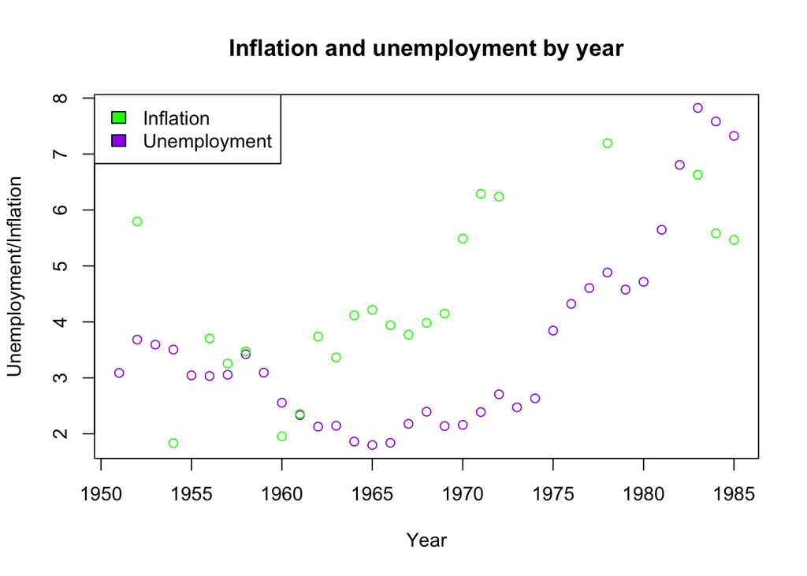

```r
plot(colnames(year_data), year_data[1,],
     xlab = "Year",
     ylab = "Unemployment/Inflation",
     main = "Inflation and unemployment by year",
     col = "purple")
points(colnames(year_data), year_data[2,],
       col = "green")
legend("topleft",
       legend = c("Inflation", "Unemployment"),
       col = c("green", "purple"),
       fill = c("green", "purple"))
```

- **2c.** Using `split()` and `sapply()`, compute the average unemployment rate for each country, pre and post 1975. The output should be a numeric vector of length 36; display the first 5 entries. Hint: the hard part here is the splitting. There are several ways to do this. One way is as follows: define a new column (say) `yearPre1975` to be the indicator that the `year` column is less than or equal to 1975. Then define a new column (say) `countryPre1975` to be the string concatenation of the `country` and `yearPre1975` columns. Then split on `countryPre1975` and proceed as usual.

```r
strikes.df$yearPre1975 <- strikes.df$year <= 1975
strikes.df$countryPre1975 <- paste(as.character(strikes.df$yearPre1975),
                                 as.character(strikes.df$country))

strikes_era <- sapply(split(strikes.df, strikes.df$countryPre1975),
                             FUN = function(country){
                               return(mean(country$unemployment))
                               })

head(strikes_era, 5)
```

```
## FALSE Australia   FALSE Austria   FALSE Belgium    FALSE Canada
##            6.84            2.54            6.90            9.00
##   FALSE Denmark
##            8.29
```

- **2d.** Compute for each country the difference in average unemployment post and pre 1975. Which country had the biggest increase in average unemployment from pre to post 1975? The biggest decrease?

```r
n <- length(strikes_era)
# Post minus pre
unemployment_diff <- sort(strikes_era[1:(n/2)] - strikes_era[((n/2) + 1):n])
unemployment_diff[1]
```

```
## FALSE Austria
##             0
```

```r
unemployment_diff[n/2]
```

```
## FALSE Netherlands
##             7.166
```

# Plyr practice

- **3a.** Install the package `plyr` if you haven’t done so already, and load it into your R session with `library(plyr)`.

```r
library(plyr)
```

- **3b.** Repeat Q1b, but now using an appropriate function from the `plyr` package to solve the question. Hint: you shouldn’t have to use `strikes.by.country` at all, you should only need one call to `d*ply()` (where `*` is at your choosing).

```r
avg_unemployment <- daply(strikes.df,
                               .(country),
                               mean_unemployment)

avg_unemployment <- sort(avg_unemployment)

cat("The highest unemployment is of:",
    names(avg_unemployment)[length(avg_unemployment)], "\n")
```

```
## The highest unemployment is of: Ireland
```

```r
cat("The lowest unemployment is of:",
    names(avg_unemployment)[1], "\n")
```

```
## The lowest unemployment is of: Switzerland
```

- **3c.** Repeat Q1c, again using an appropriate `plyr` function. Hint: use `dlply()`. **Challenge**: using `daply()` or `ddply()` likely won’t work. That is, if the `.fun` argument is a function that returns the output of `summary()` directly, then they won’t work. Explain why. Then show how to fix this, and use them to produce an array or a data frame with the correct summary statistics for each country.

```r
fivenum_by_country_ply <- dlply(strikes.df, .(country), get_fivenum)
fivenum_by_country_ply
```

```
## $Australia
## [1] 1.3 1.8 2.5 5.2 9.8
##
## $Austria
## [1] 1.0 1.7 2.0 3.5 5.8
##
## $Belgium
## [1] 1.5 2.3 2.9 5.2 7.7
##
## $Canada
## [1]  2.40  4.35  5.60  7.25 11.80
##
## $Denmark
## [1]  0.7  1.4  6.0  9.2 12.5
##
## $Finland
## [1] 0.10 1.25 2.20 4.20 7.20
##
## $France
## [1]  0.60  1.15  2.30  4.65 10.20
##
## $Germany
## [1] 0.5 0.8 2.7 4.3 8.3
##
## $Ireland
## [1]  4.6  5.7  7.3  8.9 17.0
##
## $Italy
## [1]  3.4  5.3  6.4  8.1 10.0
##
## $Japan
## [1] 1.0 1.2 1.4 2.0 2.7
##
## $Netherlands
## [1]  0.50  1.05  2.20  5.30 14.10
##
## $New.Zealand
## [1] 0.0 0.1 0.3 1.0 5.7
##
## $Norway
```

[output cut: 21 more lines]

[output not shown]

- **3d.** Repeat Q2c, again using an appropriate `plyr` function. Hint: your solution should be particularly simple compared to your solution to Q2c, as you can just use a single call to `daply()` without creating any additional columns in `strikes.df`, like you did in Q2c. Also, remember that you can use `I()` to create indicator variables on-the-fly.

```r
avg_unemployment_3d <- daply(strikes.df,
                             .(country, I(year <= 1975)),
                             .fun = function(country){
                               return(mean(country$unemployment))
                               })

avg_unemployment_3d
```

```
##              I(year <= 1975)
## country       FALSE  TRUE
##   Australia    6.84 2.172
##   Austria      2.54 2.540
##   Belgium      6.90 2.996
##   Canada       9.00 4.860
##   Denmark      8.29 4.680
##   Finland      5.40 1.440
##   France       7.04 1.640
##   Germany      5.42 2.196
##   Ireland     10.83 6.548
##   Italy        8.09 6.180
##   Japan        2.28 1.332
##   Netherlands  8.81 1.644
##   New.Zealand  2.90 0.244
##   Norway       2.21 1.116
##   Sweden       2.47 2.004
##   Switzerland  0.54 0.244
##   UK           7.86 1.688
##   USA          7.43 4.788
```